# Reproducible Research: Peer Assessment 1

## Loading and preprocessing the dataa

The working directory is supposed to be the source file location.

```r
unzip('./activity.zip')
data <- read.csv('./activity.csv', colClasses = c('integer', 'Date', 'integer'))
```

## What is mean total number of steps taken per day?

NA values are not removed when calculating the total (sum) number of steps per day as the days with NA values excluded resulted always in 0 sum and, therefore, the histogram, mean and median were altered significantly.

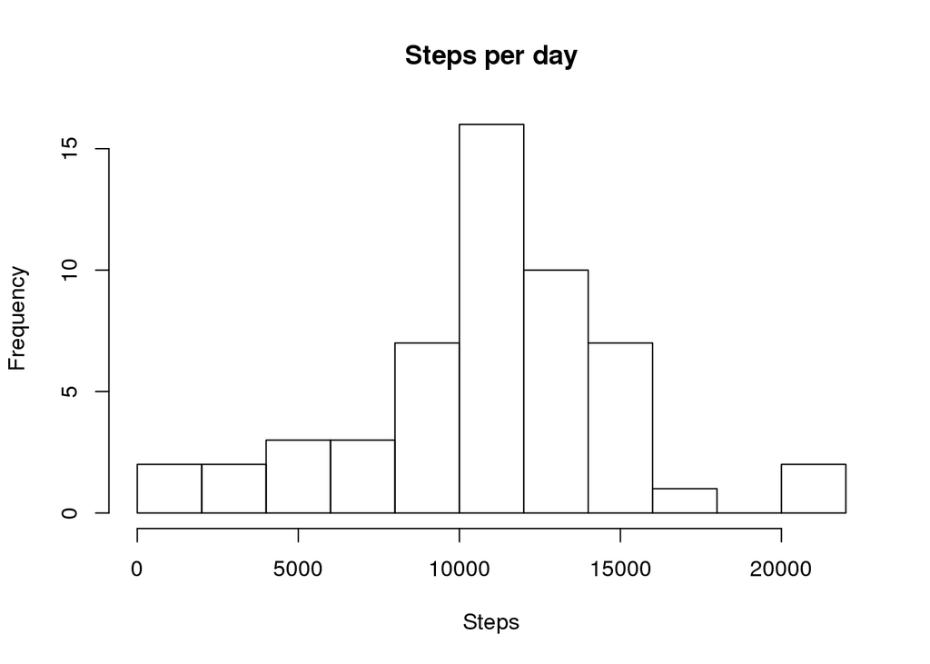

```r
sd <- aggregate(steps ~ date, data, 'sum')
hist(sd$steps, breaks = 8, main = 'Steps per day', xlab = 'Steps')
```

```r
mean <- mean(sd$steps, na.rm = TRUE)
median <- median(sd$steps, na.rm = TRUE)
# Results are embedded just bellow in text
```

The mean total number of steps per day is **1.0766 × 10<sup>4</sup>** and the median is **10765**.

## What is the average daily activity pattern?

This time NA values are excluded when calculating the mean accross all the intervals.

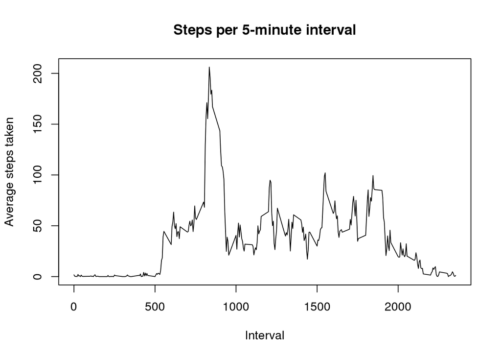

```r
si <- aggregate(steps ~ interval, data, 'mean', na.rm = TRUE)
plot(si, type = 'l', main = 'Steps per 5-minute interval',
     xlab = 'Interval', ylab = 'Average steps taken')
```

```r
interval <- si$interval[which.max(si$steps)]
# Results are embedded just bellow in text
```

The 5-minute interval which, on average, contains the maximum number of steps is the **835** interval.

## Imputing missing values

Calculating the total number of NAs can be done in many different ways. Here is calculated using the vector which contains their indexes in the data frame, as those values will be used later.

```r
na_index <- which(is.na(data))
n_na <- length(na_index)
```

The the total number of missing values in the dataset is **2304**.

```r
data2 <- data
for (i in na_index) {
    data2[i, 'steps'] <- si[si$interval == data2[i, 'interval'], 'steps']
}
```

Analyzing the new data frame with no missing values:

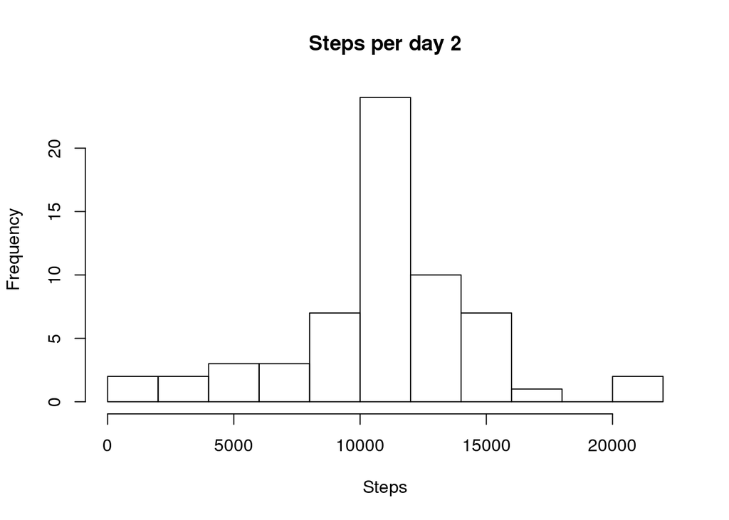

```r
sd2 <- aggregate(steps ~ date, data2, 'sum')
hist(sd2$steps, breaks = 8, main = 'Steps per day 2', xlab = 'Steps')
```

```r
mean2 <- mean(sd2$steps, na.rm = TRUE)
median2 <- median(sd2$steps, na.rm = TRUE)
# Results are embedded just bellow in text
```

The mean total number of steps per day is **1.0766 × 10<sup>4</sup>** and the median is **1.0766 × 10<sup>4</sup>**. These values do not differ from those calculated in the first part of the assigment. The only change is in the frequency (the estimates of the total daily number of steps), as now there are more days with a total number of steps equal to the mean, and therefore, the middle bar/frequency has a big peak in the histogram (the other bars are unnaltered).

## Are there differences in activity patterns between weekdays and weekends?

A new column will be added to $data$ to represent if that day is Saturday or Sunday (weekend day):

```r
data$iswe <- weekdays(data$date) %in% c('Saturday', 'Sunday')
```

Plotting the data:

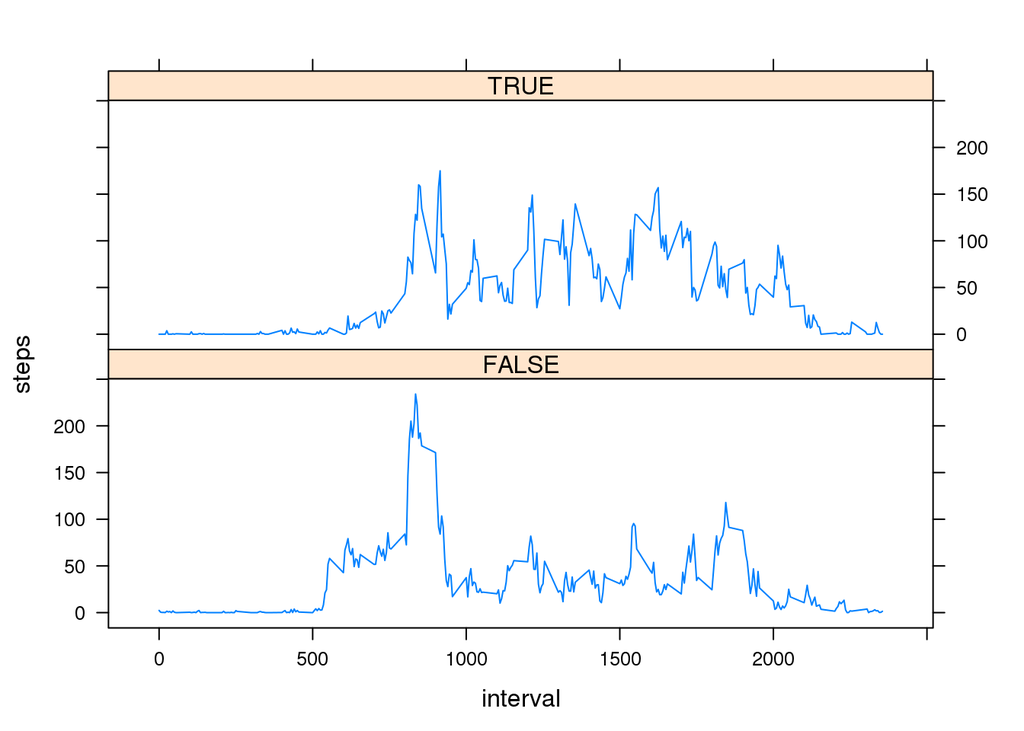

```r
library(lattice)
summary <- aggregate(steps ~ interval + iswe, data, 'mean')
xyplot(steps ~ interval | iswe, summary, layout = c(1, 2), type = 'l')
```

There are some differences between weekends and weekdays: during weekends, the number of steps is more constant during all day (excluding sleeping hours), while the rest of the days, the number of steps tend to be lower except for peaks at rush hours. The main peak is in the morning, probably before going to work, which may show that people are in general more motivated (less tired) to walk than in the afternoon when going back home.

Thanks for taking the time to read this and excuse any language mistakes, which I bet may make the reading more difficult. :-)